# Quiz 230828

coop711

2023-08-28

## Red, Black을 잘못 표시한 사람들

랜덤화출석부(8월 22일 기준)에 있는 Red, Black 과 실제 구글예습설문지에 올린 Red, Black 이 다른 사람들의 분포를 파악해 보았습니다. 랜덤화 효과는 여기서도 작동하고 있는 걸 알 수 있습니다. Red를 Black 이라고 한 사람의 수효(20명)과 Black을 Red 라고 한 사람의 수효(19명)이 비슷합니다 group 을 잘못 기억하고 있는 사람들의 수효조차 Red, Black 에 비슷하게 나뉘었습니다.

|  | Red(구글예습퀴즈) | Black(구글예습퀴즈) |
| --- | --- | --- |
| **Red(랜덤화출석부)** | 416 | 20 |
| **Black(랜덤화출석부)** | 19 | 425 |

# Quiz 응답 비교

## Q1. Dewey as good as elected, statistics convince Roper

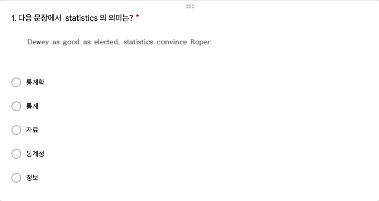

### Roper(Counts)

|  | 통계학 | 통계 | 자료 | 통계청 | 정보 | 계 |
| --- | --- | --- | --- | --- | --- | --- |
| **Red** | 47 | 357 | 22 | 5 | 4 | 435 |
| **Black** | 38 | 370 | 22 | 9 | 6 | 445 |
| **계** | 85 | 727 | 44 | 14 | 10 | 880 |

Pearson’s Chi-squared test with simulated p-value (based on 2000 replicates): `.`

| Test statistic | df | P value |
| --- | --- | --- |
| 2.615 | NA | 0.6342 |

### Roper(%)

| 통계학 | 통계 | 자료 | 통계청 | 정보 | 계 |
| --- | --- | --- | --- | --- | --- |
| 9.7 | 82.6 | 5.0 | 1.6 | 1.1 | 100.0 |

## Q2. Statistics is the science of learning from data, …

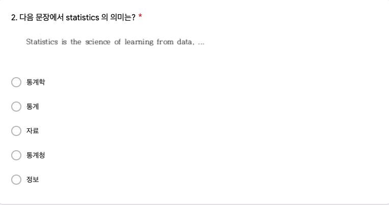

### ASA(Counts)

|  | 통계학 | 통계 | 자료 | 통계청 | 정보 | 계 |
| --- | --- | --- | --- | --- | --- | --- |
| **Red** | 373 | 51 | 6 | 2 | 3 | 435 |
| **Black** | 380 | 51 | 8 | 1 | 5 | 445 |
| **계** | 753 | 102 | 14 | 3 | 8 | 880 |

Pearson’s Chi-squared test with simulated p-value (based on 2000 replicates): `.`

| Test statistic | df | P value |
| --- | --- | --- |
| 1.071 | NA | 0.92 |

### ASA(%)

| 통계학 | 통계 | 자료 | 통계청 | 정보 | 계 |
| --- | --- | --- | --- | --- | --- |
| 85.6 | 11.6 | 1.6 | 0.3 | 0.9 | 100.0 |

## Q3. How to lie with statistics

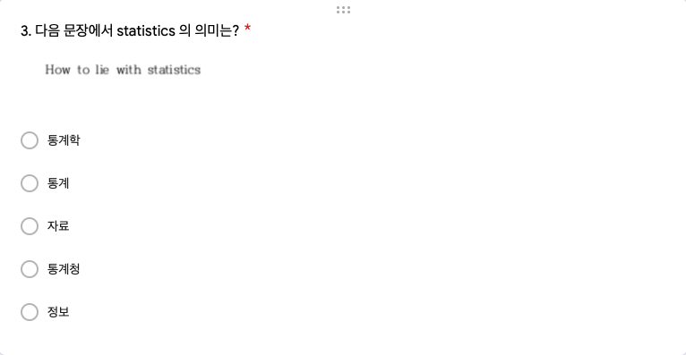

### D.Huff(Counts)

|  | 통계학 | 통계 | 자료 | 통계청 | 정보 | 계 |
| --- | --- | --- | --- | --- | --- | --- |
| **Red** | 31 | 323 | 41 | 12 | 28 | 435 |
| **Black** | 30 | 322 | 51 | 16 | 26 | 445 |
| **계** | 61 | 645 | 92 | 28 | 54 | 880 |

Pearson’s Chi-squared test: `.`

| Test statistic | df | P value |
| --- | --- | --- |
| 1.637 | 4 | 0.8021 |

### D.Huff(%)

| 통계학 | 통계 | 자료 | 통계청 | 정보 | 계 |
| --- | --- | --- | --- | --- | --- |
| 6.9 | 73.3 | 10.5 | 3.2 | 6.1 | 100.0 |

# Q4. 비핵화

## 질문지 선택지에 부연설명

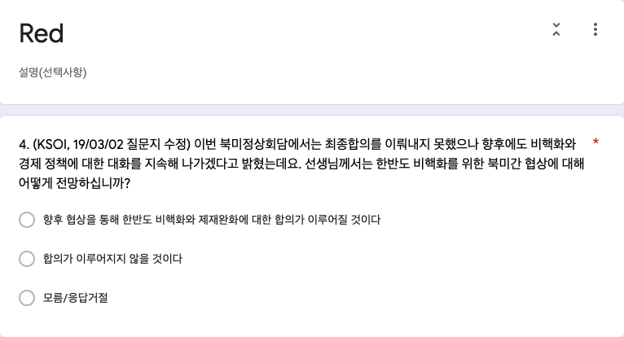

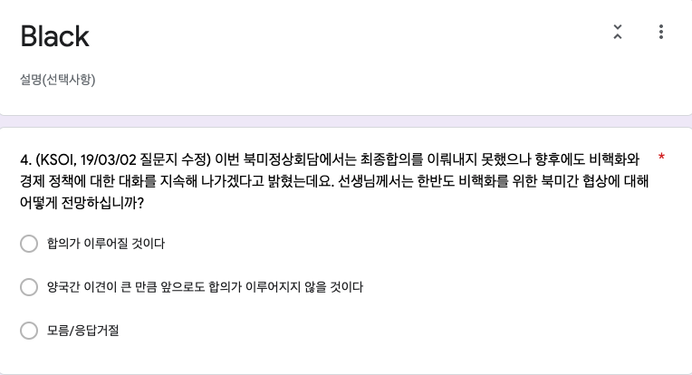

### 집계

합의가 이루어질 것이라는 선택지에 부연설명을 붙이거나(Red), 합의가 이루어지지 않을 것이라는 선택지에 부연설명을 붙였을 때(Black), 부연설명의 여부에 따라 응답이 달라지는 지 살펴본 결과 기대한 바와 같이 양 집단에 통계적으로 유의한 수준의 차이가 났습니다. 전체적으로 합의가 이루어지지 않을 것이라는 응답이 주류를 이루는 가운데에도 합의가 이루어지지 않는 이유를 추가한 Black 집단에서 훨씬 높은 비율로 합의가 이루어지지 않을 것이라는 응답이 나왔습니다. 앞에서 본 바와 Red, Black 두 집단은 출석부의 다섯 변수에 있어서 매우 닮은 집단이어서 Q1, Q2, Q3의 응답 결과에서 본 바와 같이 그 응답이 매우 닮게 나오는데 만약 부연설명이 효과가 없다면 Q4에서의 응답도 닮게 나왔을 것입니다. 그러지 못한 이유를 따져보면 바로 부연설명을 붙였다는 데서 차이가 난다고 결론을 내릴 수 있는 것입니다.

|  | 합의가 이루어질 것이다 | 합의가 이루어지지 않을 것이다 | 모름/응답거절 | 계 |
| --- | --- | --- | --- | --- |
| **Red** | 136 | 217 | 82 | 435 |
| **Black** | 81 | 296 | 68 | 445 |
| **계** | 217 | 513 | 150 | 880 |

Pearson’s Chi-squared test: `.`

| Test statistic | df | P value |
| --- | --- | --- |
| 27.3 | 2 | 1.179e-06 * * * |

### % 비교.

|  | 합의가 이루어질 것이다 | 합의가 이루어지지 않을 것이다 | 모름/응답거절 | 계 |
| --- | --- | --- | --- | --- |
| **Red** | 31.3 | 49.9 | 18.9 | 100.0 |
| **Black** | 18.2 | 66.5 | 15.3 | 100.0 |

### Mosaic Plot

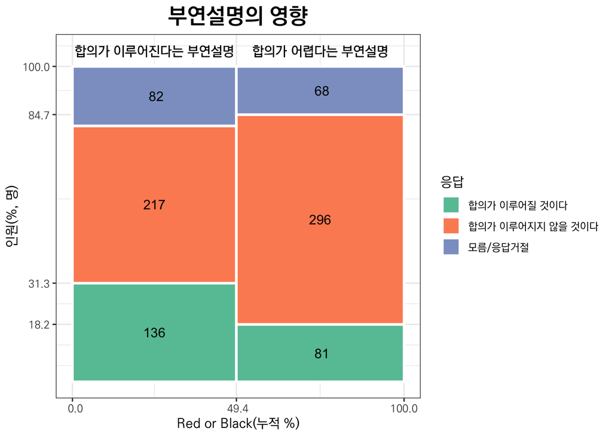

# 제출 시간의 분포

과제 제출이 제출 기간 마지막 날에 몰린다는 것을 시각적으로 보여주고 싶어서 하나 추가하였습니다. 아직은 학기초라 덜 한데, 중반 이후가 되면 마지막 날, 그것도 오후2시부터 몰리는 현상을 관찰할 수 있습니다. 여기서조차 랜덤화 효과를 관찰할 수 있네요. p-value 에 유의해 주세요. 제출시간과 관련한 두 가지 현상에 대해서도 여러분의 생각을 들어보고 싶습니다. 첫째, 랜덤화 효과. 둘쨰, 마감날에 몰리는 현상.

### 일 단위 마감 시간으로부터 제출 시간의 분포

### 분포표

일 단위

|  | [0,1] | (1,2] | (2,3] | (3,4] | (4,5] | (5,6] | (6,7] | (7,8] | (8,9] | (9,10] | (10,11] | (11,12] | (12,13] | (13,14] |
| --- | --- | --- | --- | --- | --- | --- | --- | --- | --- | --- | --- | --- | --- | --- |
| **Red** | 25 | 10 | 8 | 4 | 5 | 5 | 12 | 100 | 58 | 41 | 24 | 41 | 41 | 61 |
| **Black** | 29 | 9 | 6 | 4 | 3 | 6 | 13 | 92 | 60 | 46 | 31 | 49 | 46 | 50 |

Pearson’s Chi-squared test with simulated p-value (based on 2000 replicates): `.`

| Test statistic | df | P value |
| --- | --- | --- |
| 4.808 | NA | 0.977 |

### 막대그래프

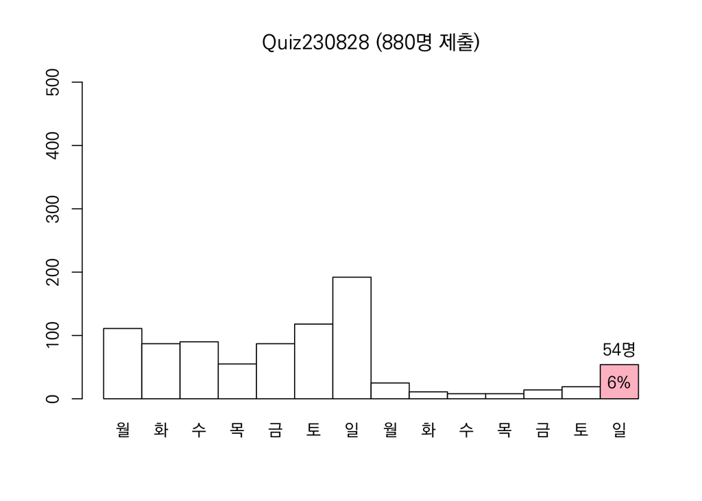

### Mosaic Plot

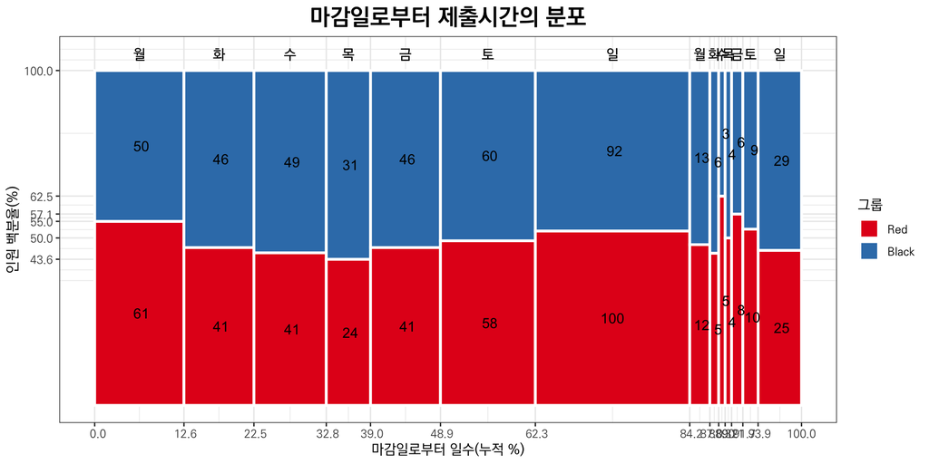